# Risk Factor Analysis

## Outcome Variable

**Outcome Variable:** ever_swasted

## Predictor Variables

**Intervention Variable:** birthwt

**Adjustment Set:**

- arm
- sex
- W_mage
- meducyrs
- feducyrs
- vagbrth
- single
- brthmon
- W_parity
- delta_W_mage
- delta_meducyrs
- delta_feducyrs
- delta_vagbrth
- delta_single
- delta_brthmon
- delta_W_parity

## Stratifying Variables

The analysis was stratified on these variable(s):

- agecat
- studyid
- country

## Data Summary

| agecat | studyid | country | birthwt | ever_swasted | n_cell | n |
| --- | --- | --- | --- | --- | --- | --- |
| 0-24 months (no birth wast) | ki0047075b-MAL-ED | BANGLADESH | Normal or high birthweight | 0 | 195 | 257 |
| 0-24 months (no birth wast) | ki0047075b-MAL-ED | BANGLADESH | Normal or high birthweight | 1 | 9 | 257 |
| 0-24 months (no birth wast) | ki0047075b-MAL-ED | BANGLADESH | Low birth weight | 0 | 50 | 257 |
| 0-24 months (no birth wast) | ki0047075b-MAL-ED | BANGLADESH | Low birth weight | 1 | 3 | 257 |
| 0-24 months (no birth wast) | ki0047075b-MAL-ED | BRAZIL | Normal or high birthweight | 0 | 217 | 232 |
| 0-24 months (no birth wast) | ki0047075b-MAL-ED | BRAZIL | Normal or high birthweight | 1 | 3 | 232 |
| 0-24 months (no birth wast) | ki0047075b-MAL-ED | BRAZIL | Low birth weight | 0 | 12 | 232 |
| 0-24 months (no birth wast) | ki0047075b-MAL-ED | BRAZIL | Low birth weight | 1 | 0 | 232 |
| 0-24 months (no birth wast) | ki0047075b-MAL-ED | INDIA | Normal or high birthweight | 0 | 193 | 238 |
| 0-24 months (no birth wast) | ki0047075b-MAL-ED | INDIA | Normal or high birthweight | 1 | 9 | 238 |
| 0-24 months (no birth wast) | ki0047075b-MAL-ED | INDIA | Low birth weight | 0 | 36 | 238 |
| 0-24 months (no birth wast) | ki0047075b-MAL-ED | INDIA | Low birth weight | 1 | 0 | 238 |
| 0-24 months (no birth wast) | ki0047075b-MAL-ED | NEPAL | Normal or high birthweight | 0 | 210 | 232 |
| 0-24 months (no birth wast) | ki0047075b-MAL-ED | NEPAL | Normal or high birthweight | 1 | 1 | 232 |
| 0-24 months (no birth wast) | ki0047075b-MAL-ED | NEPAL | Low birth weight | 0 | 21 | 232 |
| 0-24 months (no birth wast) | ki0047075b-MAL-ED | NEPAL | Low birth weight | 1 | 0 | 232 |
| 0-24 months (no birth wast) | ki0047075b-MAL-ED | PERU | Normal or high birthweight | 0 | 278 | 299 |
| 0-24 months (no birth wast) | ki0047075b-MAL-ED | PERU | Normal or high birthweight | 1 | 3 | 299 |
| 0-24 months (no birth wast) | ki0047075b-MAL-ED | PERU | Low birth weight | 0 | 18 | 299 |
| 0-24 months (no birth wast) | ki0047075b-MAL-ED | PERU | Low birth weight | 1 | 0 | 299 |
| 0-24 months (no birth wast) | ki0047075b-MAL-ED | SOUTH AFRICA | Normal or high birthweight | 0 | 277 | 308 |
| 0-24 months (no birth wast) | ki0047075b-MAL-ED | SOUTH AFRICA | Normal or high birthweight | 1 | 10 | 308 |
| 0-24 months (no birth wast) | ki0047075b-MAL-ED | SOUTH AFRICA | Low birth weight | 0 | 20 | 308 |
| 0-24 months (no birth wast) | ki0047075b-MAL-ED | SOUTH AFRICA | Low birth weight | 1 | 1 | 308 |
| 0-24 months (no birth wast) | ki0047075b-MAL-ED | TANZANIA, UNITED REPUBLIC OF | Normal or high birthweight | 0 | 126 | 135 |
| 0-24 months (no birth wast) | ki0047075b-MAL-ED | TANZANIA, UNITED REPUBLIC OF | Normal or high birthweight | 1 | 2 | 135 |
| 0-24 months (no birth wast) | ki0047075b-MAL-ED | TANZANIA, UNITED REPUBLIC OF | Low birth weight | 0 | 7 | 135 |
| 0-24 months (no birth wast) | ki0047075b-MAL-ED | TANZANIA, UNITED REPUBLIC OF | Low birth weight | 1 | 0 | 135 |
| 0-24 months (no birth wast) | ki1000108-CMC-V-BCS-2002 | INDIA | Normal or high birthweight | 0 | 278 | 368 |
| 0-24 months (no birth wast) | ki1000108-CMC-V-BCS-2002 | INDIA | Normal or high birthweight | 1 | 50 | 368 |

[output cut: 318 more lines]

The following strata were considered:

- agecat: 0-24 months (no birth wast), studyid: ki0047075b-MAL-ED, country: BANGLADESH
- agecat: 0-24 months (no birth wast), studyid: ki0047075b-MAL-ED, country: BRAZIL
- agecat: 0-24 months (no birth wast), studyid: ki0047075b-MAL-ED, country: INDIA
- agecat: 0-24 months (no birth wast), studyid: ki0047075b-MAL-ED, country: NEPAL
- agecat: 0-24 months (no birth wast), studyid: ki0047075b-MAL-ED, country: PERU
- agecat: 0-24 months (no birth wast), studyid: ki0047075b-MAL-ED, country: SOUTH AFRICA
- agecat: 0-24 months (no birth wast), studyid: ki0047075b-MAL-ED, country: TANZANIA, UNITED REPUBLIC OF
- agecat: 0-24 months (no birth wast), studyid: ki1000108-CMC-V-BCS-2002, country: INDIA
- agecat: 0-24 months (no birth wast), studyid: ki1000108-IRC, country: INDIA
- agecat: 0-24 months (no birth wast), studyid: ki1000109-EE, country: PAKISTAN
- agecat: 0-24 months (no birth wast), studyid: ki1000109-ResPak, country: PAKISTAN
- agecat: 0-24 months (no birth wast), studyid: ki1000304b-SAS-CompFeed, country: INDIA
- agecat: 0-24 months (no birth wast), studyid: ki1017093-NIH-Birth, country: BANGLADESH
- agecat: 0-24 months (no birth wast), studyid: ki1017093b-PROVIDE, country: BANGLADESH
- agecat: 0-24 months (no birth wast), studyid: ki1017093c-NIH-Crypto, country: BANGLADESH
- agecat: 0-24 months (no birth wast), studyid: ki1066203-TanzaniaChild2, country: TANZANIA, UNITED REPUBLIC OF
- agecat: 0-24 months (no birth wast), studyid: ki1101329-Keneba, country: GAMBIA
- agecat: 0-24 months (no birth wast), studyid: ki1114097-CMIN, country: BANGLADESH
- agecat: 0-24 months (no birth wast), studyid: ki1114097-CMIN, country: BRAZIL
- agecat: 0-24 months (no birth wast), studyid: ki1114097-CMIN, country: GUINEA-BISSAU
- agecat: 0-24 months (no birth wast), studyid: ki1114097-CMIN, country: PERU
- agecat: 0-24 months (no birth wast), studyid: ki1114097-CONTENT, country: PERU
- agecat: 0-24 months (no birth wast), studyid: ki1119695-PROBIT, country: BELARUS
- agecat: 0-24 months (no birth wast), studyid: ki1126311-ZVITAMBO, country: ZIMBABWE
- agecat: 0-24 months (no birth wast), studyid: ki1135781-COHORTS, country: GUATEMALA
- agecat: 0-24 months (no birth wast), studyid: ki1135781-COHORTS, country: INDIA
- agecat: 0-24 months (no birth wast), studyid: ki1135781-COHORTS, country: PHILIPPINES
- agecat: 0-24 months (no birth wast), studyid: kiGH5241-JiVitA-3, country: BANGLADESH
- agecat: 0-24 months (no birth wast), studyid: kiGH5241-JiVitA-4, country: BANGLADESH
- agecat: 0-6 months (no birth wast), studyid: ki0047075b-MAL-ED, country: BANGLADESH
- agecat: 0-6 months (no birth wast), studyid: ki0047075b-MAL-ED, country: BRAZIL
- agecat: 0-6 months (no birth wast), studyid: ki0047075b-MAL-ED, country: INDIA
- agecat: 0-6 months (no birth wast), studyid: ki0047075b-MAL-ED, country: NEPAL
- agecat: 0-6 months (no birth wast), studyid: ki0047075b-MAL-ED, country: PERU
- agecat: 0-6 months (no birth wast), studyid: ki0047075b-MAL-ED, country: SOUTH AFRICA
- agecat: 0-6 months (no birth wast), studyid: ki0047075b-MAL-ED, country: TANZANIA, UNITED REPUBLIC OF
- agecat: 0-6 months (no birth wast), studyid: ki1000108-CMC-V-BCS-2002, country: INDIA
- agecat: 0-6 months (no birth wast), studyid: ki1000108-IRC, country: INDIA
- agecat: 0-6 months (no birth wast), studyid: ki1000109-EE, country: PAKISTAN
- agecat: 0-6 months (no birth wast), studyid: ki1000109-ResPak, country: PAKISTAN
- agecat: 0-6 months (no birth wast), studyid: ki1000304b-SAS-CompFeed, country: INDIA
- agecat: 0-6 months (no birth wast), studyid: ki1017093-NIH-Birth, country: BANGLADESH
- agecat: 0-6 months (no birth wast), studyid: ki1017093b-PROVIDE, country: BANGLADESH
- agecat: 0-6 months (no birth wast), studyid: ki1017093c-NIH-Crypto, country: BANGLADESH
- agecat: 0-6 months (no birth wast), studyid: ki1066203-TanzaniaChild2, country: TANZANIA, UNITED REPUBLIC OF
- agecat: 0-6 months (no birth wast), studyid: ki1101329-Keneba, country: GAMBIA
- agecat: 0-6 months (no birth wast), studyid: ki1114097-CMIN, country: BANGLADESH
- agecat: 0-6 months (no birth wast), studyid: ki1114097-CMIN, country: BRAZIL
- agecat: 0-6 months (no birth wast), studyid: ki1114097-CMIN, country: GUINEA-BISSAU
- agecat: 0-6 months (no birth wast), studyid: ki1114097-CMIN, country: PERU
- agecat: 0-6 months (no birth wast), studyid: ki1114097-CONTENT, country: PERU
- agecat: 0-6 months (no birth wast), studyid: ki1119695-PROBIT, country: BELARUS
- agecat: 0-6 months (no birth wast), studyid: ki1126311-ZVITAMBO, country: ZIMBABWE
- agecat: 0-6 months (no birth wast), studyid: ki1135781-COHORTS, country: GUATEMALA
- agecat: 0-6 months (no birth wast), studyid: ki1135781-COHORTS, country: INDIA
- agecat: 0-6 months (no birth wast), studyid: ki1135781-COHORTS, country: PHILIPPINES
- agecat: 0-6 months (no birth wast), studyid: kiGH5241-JiVitA-3, country: BANGLADESH
- agecat: 0-6 months (no birth wast), studyid: kiGH5241-JiVitA-4, country: BANGLADESH
- agecat: 6-24 months, studyid: ki0047075b-MAL-ED, country: BANGLADESH
- agecat: 6-24 months, studyid: ki0047075b-MAL-ED, country: BRAZIL
- agecat: 6-24 months, studyid: ki0047075b-MAL-ED, country: INDIA
- agecat: 6-24 months, studyid: ki0047075b-MAL-ED, country: NEPAL
- agecat: 6-24 months, studyid: ki0047075b-MAL-ED, country: PERU
- agecat: 6-24 months, studyid: ki0047075b-MAL-ED, country: SOUTH AFRICA
- agecat: 6-24 months, studyid: ki0047075b-MAL-ED, country: TANZANIA, UNITED REPUBLIC OF
- agecat: 6-24 months, studyid: ki1000108-CMC-V-BCS-2002, country: INDIA
- agecat: 6-24 months, studyid: ki1000108-IRC, country: INDIA
- agecat: 6-24 months, studyid: ki1000109-EE, country: PAKISTAN
- agecat: 6-24 months, studyid: ki1000109-ResPak, country: PAKISTAN
- agecat: 6-24 months, studyid: ki1000304b-SAS-CompFeed, country: INDIA
- agecat: 6-24 months, studyid: ki1017093-NIH-Birth, country: BANGLADESH
- agecat: 6-24 months, studyid: ki1017093b-PROVIDE, country: BANGLADESH
- agecat: 6-24 months, studyid: ki1017093c-NIH-Crypto, country: BANGLADESH
- agecat: 6-24 months, studyid: ki1066203-TanzaniaChild2, country: TANZANIA, UNITED REPUBLIC OF
- agecat: 6-24 months, studyid: ki1101329-Keneba, country: GAMBIA
- agecat: 6-24 months, studyid: ki1114097-CMIN, country: BANGLADESH
- agecat: 6-24 months, studyid: ki1114097-CMIN, country: BRAZIL
- agecat: 6-24 months, studyid: ki1114097-CMIN, country: GUINEA-BISSAU
- agecat: 6-24 months, studyid: ki1114097-CMIN, country: PERU
- agecat: 6-24 months, studyid: ki1114097-CONTENT, country: PERU
- agecat: 6-24 months, studyid: ki1119695-PROBIT, country: BELARUS
- agecat: 6-24 months, studyid: ki1126311-ZVITAMBO, country: ZIMBABWE
- agecat: 6-24 months, studyid: ki1135781-COHORTS, country: GUATEMALA
- agecat: 6-24 months, studyid: ki1135781-COHORTS, country: INDIA
- agecat: 6-24 months, studyid: ki1135781-COHORTS, country: PHILIPPINES
- agecat: 6-24 months, studyid: kiGH5241-JiVitA-3, country: BANGLADESH
- agecat: 6-24 months, studyid: kiGH5241-JiVitA-4, country: BANGLADESH

### Dropped Strata

Some strata were dropped due to rare outcomes:

- agecat: 0-24 months (no birth wast), studyid: ki0047075b-MAL-ED, country: BANGLADESH
- agecat: 0-24 months (no birth wast), studyid: ki0047075b-MAL-ED, country: BRAZIL
- agecat: 0-24 months (no birth wast), studyid: ki0047075b-MAL-ED, country: INDIA
- agecat: 0-24 months (no birth wast), studyid: ki0047075b-MAL-ED, country: NEPAL
- agecat: 0-24 months (no birth wast), studyid: ki0047075b-MAL-ED, country: PERU
- agecat: 0-24 months (no birth wast), studyid: ki0047075b-MAL-ED, country: SOUTH AFRICA
- agecat: 0-24 months (no birth wast), studyid: ki0047075b-MAL-ED, country: TANZANIA, UNITED REPUBLIC OF
- agecat: 0-24 months (no birth wast), studyid: ki1000109-ResPak, country: PAKISTAN
- agecat: 0-24 months (no birth wast), studyid: ki1114097-CMIN, country: BANGLADESH
- agecat: 0-24 months (no birth wast), studyid: ki1114097-CMIN, country: BRAZIL
- agecat: 0-24 months (no birth wast), studyid: ki1114097-CMIN, country: GUINEA-BISSAU
- agecat: 0-24 months (no birth wast), studyid: ki1114097-CMIN, country: PERU
- agecat: 0-24 months (no birth wast), studyid: ki1114097-CONTENT, country: PERU
- agecat: 0-24 months (no birth wast), studyid: ki1119695-PROBIT, country: BELARUS
- agecat: 0-6 months (no birth wast), studyid: ki0047075b-MAL-ED, country: BANGLADESH
- agecat: 0-6 months (no birth wast), studyid: ki0047075b-MAL-ED, country: BRAZIL
- agecat: 0-6 months (no birth wast), studyid: ki0047075b-MAL-ED, country: INDIA
- agecat: 0-6 months (no birth wast), studyid: ki0047075b-MAL-ED, country: NEPAL
- agecat: 0-6 months (no birth wast), studyid: ki0047075b-MAL-ED, country: PERU
- agecat: 0-6 months (no birth wast), studyid: ki0047075b-MAL-ED, country: SOUTH AFRICA
- agecat: 0-6 months (no birth wast), studyid: ki0047075b-MAL-ED, country: TANZANIA, UNITED REPUBLIC OF
- agecat: 0-6 months (no birth wast), studyid: ki1000108-CMC-V-BCS-2002, country: INDIA
- agecat: 0-6 months (no birth wast), studyid: ki1000109-EE, country: PAKISTAN
- agecat: 0-6 months (no birth wast), studyid: ki1000109-ResPak, country: PAKISTAN
- agecat: 0-6 months (no birth wast), studyid: ki1017093-NIH-Birth, country: BANGLADESH
- agecat: 0-6 months (no birth wast), studyid: ki1017093b-PROVIDE, country: BANGLADESH
- agecat: 0-6 months (no birth wast), studyid: ki1017093c-NIH-Crypto, country: BANGLADESH
- agecat: 0-6 months (no birth wast), studyid: ki1066203-TanzaniaChild2, country: TANZANIA, UNITED REPUBLIC OF
- agecat: 0-6 months (no birth wast), studyid: ki1114097-CMIN, country: BANGLADESH
- agecat: 0-6 months (no birth wast), studyid: ki1114097-CMIN, country: BRAZIL
- agecat: 0-6 months (no birth wast), studyid: ki1114097-CMIN, country: GUINEA-BISSAU
- agecat: 0-6 months (no birth wast), studyid: ki1114097-CMIN, country: PERU
- agecat: 0-6 months (no birth wast), studyid: ki1114097-CONTENT, country: PERU
- agecat: 0-6 months (no birth wast), studyid: ki1119695-PROBIT, country: BELARUS
- agecat: 0-6 months (no birth wast), studyid: ki1135781-COHORTS, country: GUATEMALA
- agecat: 6-24 months, studyid: ki0047075b-MAL-ED, country: BANGLADESH
- agecat: 6-24 months, studyid: ki0047075b-MAL-ED, country: BRAZIL
- agecat: 6-24 months, studyid: ki0047075b-MAL-ED, country: INDIA
- agecat: 6-24 months, studyid: ki0047075b-MAL-ED, country: NEPAL
- agecat: 6-24 months, studyid: ki0047075b-MAL-ED, country: PERU
- agecat: 6-24 months, studyid: ki0047075b-MAL-ED, country: SOUTH AFRICA
- agecat: 6-24 months, studyid: ki0047075b-MAL-ED, country: TANZANIA, UNITED REPUBLIC OF
- agecat: 6-24 months, studyid: ki1000109-ResPak, country: PAKISTAN
- agecat: 6-24 months, studyid: ki1114097-CMIN, country: BANGLADESH
- agecat: 6-24 months, studyid: ki1114097-CMIN, country: BRAZIL
- agecat: 6-24 months, studyid: ki1114097-CMIN, country: GUINEA-BISSAU
- agecat: 6-24 months, studyid: ki1114097-CMIN, country: PERU
- agecat: 6-24 months, studyid: ki1114097-CONTENT, country: PERU
- agecat: 6-24 months, studyid: ki1119695-PROBIT, country: BELARUS

## Methods Detail

We’re interested in the causal parameters $E[Y_a]$ for all values of $a \in \mathcal{A}$. These parameters represent the mean outcome if, possibly contrary to fact, we intervened to set all units to have $A=a$. Under the randomization and positivity assumptions, these are identified by the statistical parameters $\psi_a=E_W[E_{Y|A,W}(Y|A=a,W)]$. In addition, we’re interested in the mean of $Y$, $E[Y]$ under no intervention (the observed mean). We will estimate these parameters by using SuperLearner to fit the relevant likelihood factors – $E_{Y|A,W}(Y|A=a,W)$ and $p(A=a|W)$, and then updating our likelihood fit using a joint TMLE.

For unadjusted analyses ($W=\{\}$), initial likelihoods were estimated using Lrnr_glm to estimate the simple $E(Y|A)$ and Lrnr_mean to estimate $p(A)$. For adjusted analyses, a small library containing Lrnr_glmnet, Lrnr_xgboost, and Lrnr_mean was used.

Having estimated these parameters, we will then use the delta method to estimate relative risks and attributable risks relative to a prespecified baseline level of $A$.

# Results Detail

## Results Plots

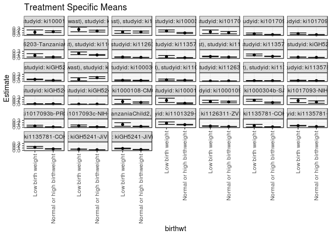

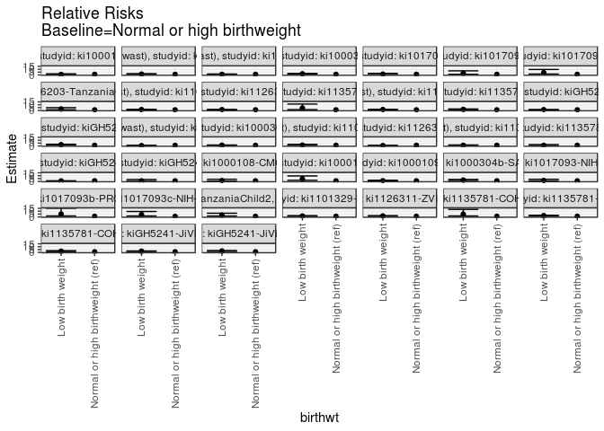

[figure not shown]

[figure not shown]

## Results Table

### Parameter: TSM

| agecat | studyid | country | intervention_level | baseline_level | estimate | ci_lower | ci_upper |
| --- | --- | --- | --- | --- | --- | --- | --- |
| 0-24 months (no birth wast) | ki1000108-CMC-V-BCS-2002 | INDIA | Normal or high birthweight | NA | 0.1524390 | 0.1134865 | 0.1913915 |
| 0-24 months (no birth wast) | ki1000108-CMC-V-BCS-2002 | INDIA | Low birth weight | NA | 0.1250000 | 0.0223715 | 0.2276285 |
| 0-24 months (no birth wast) | ki1000108-IRC | INDIA | Normal or high birthweight | NA | 0.1772092 | 0.1364961 | 0.2179224 |
| 0-24 months (no birth wast) | ki1000108-IRC | INDIA | Low birth weight | NA | 0.2508570 | 0.1472233 | 0.3544907 |
| 0-24 months (no birth wast) | ki1000109-EE | PAKISTAN | Normal or high birthweight | NA | 0.1359198 | 0.0929616 | 0.1788781 |
| 0-24 months (no birth wast) | ki1000109-EE | PAKISTAN | Low birth weight | NA | 0.1366763 | 0.0787197 | 0.1946328 |
| 0-24 months (no birth wast) | ki1000304b-SAS-CompFeed | INDIA | Normal or high birthweight | NA | 0.0933467 | 0.0703683 | 0.1163252 |
| 0-24 months (no birth wast) | ki1000304b-SAS-CompFeed | INDIA | Low birth weight | NA | 0.1836656 | 0.1394396 | 0.2278917 |
| 0-24 months (no birth wast) | ki1017093-NIH-Birth | BANGLADESH | Normal or high birthweight | NA | 0.1066219 | 0.0548129 | 0.1584308 |
| 0-24 months (no birth wast) | ki1017093-NIH-Birth | BANGLADESH | Low birth weight | NA | 0.1449145 | 0.0643204 | 0.2255086 |
| 0-24 months (no birth wast) | ki1017093b-PROVIDE | BANGLADESH | Normal or high birthweight | NA | 0.0189394 | 0.0073041 | 0.0305747 |
| 0-24 months (no birth wast) | ki1017093b-PROVIDE | BANGLADESH | Low birth weight | NA | 0.0566038 | 0.0206590 | 0.0925485 |
| 0-24 months (no birth wast) | ki1017093c-NIH-Crypto | BANGLADESH | Normal or high birthweight | NA | 0.0155440 | 0.0054613 | 0.0256267 |
| 0-24 months (no birth wast) | ki1017093c-NIH-Crypto | BANGLADESH | Low birth weight | NA | 0.0628571 | 0.0268741 | 0.0988402 |
| 0-24 months (no birth wast) | ki1066203-TanzaniaChild2 | TANZANIA, UNITED REPUBLIC OF | Normal or high birthweight | NA | 0.0473931 | 0.0386668 | 0.0561193 |
| 0-24 months (no birth wast) | ki1066203-TanzaniaChild2 | TANZANIA, UNITED REPUBLIC OF | Low birth weight | NA | 0.1223591 | 0.0476280 | 0.1970903 |
| 0-24 months (no birth wast) | ki1101329-Keneba | GAMBIA | Normal or high birthweight | NA | 0.1402861 | 0.1246513 | 0.1559208 |
| 0-24 months (no birth wast) | ki1101329-Keneba | GAMBIA | Low birth weight | NA | 0.2135306 | 0.1534502 | 0.2736111 |
| 0-24 months (no birth wast) | ki1126311-ZVITAMBO | ZIMBABWE | Normal or high birthweight | NA | 0.0328836 | 0.0296780 | 0.0360892 |
| 0-24 months (no birth wast) | ki1126311-ZVITAMBO | ZIMBABWE | Low birth weight | NA | 0.0456336 | 0.0353107 | 0.0559565 |
| 0-24 months (no birth wast) | ki1135781-COHORTS | GUATEMALA | Normal or high birthweight | NA | 0.0155131 | 0.0071413 | 0.0238849 |
| 0-24 months (no birth wast) | ki1135781-COHORTS | GUATEMALA | Low birth weight | NA | 0.0632911 | 0.0095700 | 0.1170123 |
| 0-24 months (no birth wast) | ki1135781-COHORTS | INDIA | Normal or high birthweight | NA | 0.0454383 | 0.0398357 | 0.0510409 |
| 0-24 months (no birth wast) | ki1135781-COHORTS | INDIA | Low birth weight | NA | 0.0728913 | 0.0582167 | 0.0875660 |
| 0-24 months (no birth wast) | ki1135781-COHORTS | PHILIPPINES | Normal or high birthweight | NA | 0.0773540 | 0.0672720 | 0.0874360 |
| 0-24 months (no birth wast) | ki1135781-COHORTS | PHILIPPINES | Low birth weight | NA | 0.1426269 | 0.1010963 | 0.1841574 |
| 0-24 months (no birth wast) | kiGH5241-JiVitA-3 | BANGLADESH | Normal or high birthweight | NA | 0.0317363 | 0.0286554 | 0.0348173 |
| 0-24 months (no birth wast) | kiGH5241-JiVitA-3 | BANGLADESH | Low birth weight | NA | 0.0424590 | 0.0380128 | 0.0469053 |
| 0-24 months (no birth wast) | kiGH5241-JiVitA-4 | BANGLADESH | Normal or high birthweight | NA | 0.0353176 | 0.0284686 | 0.0421666 |
| 0-24 months (no birth wast) | kiGH5241-JiVitA-4 | BANGLADESH | Low birth weight | NA | 0.0780103 | 0.0612404 | 0.0947801 |
| 0-6 months (no birth wast) | ki1000108-IRC | INDIA | Normal or high birthweight | NA | 0.1585366 | 0.1189586 | 0.1981146 |
| 0-6 months (no birth wast) | ki1000108-IRC | INDIA | Low birth weight | NA | 0.0833333 | 0.0133092 | 0.1533575 |
| 0-6 months (no birth wast) | ki1000304b-SAS-CompFeed | INDIA | Normal or high birthweight | NA | 0.0296046 | 0.0183968 | 0.0408124 |
| 0-6 months (no birth wast) | ki1000304b-SAS-CompFeed | INDIA | Low birth weight | NA | 0.0365242 | 0.0164942 | 0.0565542 |
| 0-6 months (no birth wast) | ki1101329-Keneba | GAMBIA | Normal or high birthweight | NA | 0.0404462 | 0.0312088 | 0.0496836 |
| 0-6 months (no birth wast) | ki1101329-Keneba | GAMBIA | Low birth weight | NA | 0.0581996 | 0.0226769 | 0.0937223 |
| 0-6 months (no birth wast) | ki1126311-ZVITAMBO | ZIMBABWE | Normal or high birthweight | NA | 0.0102595 | 0.0084380 | 0.0120809 |
| 0-6 months (no birth wast) | ki1126311-ZVITAMBO | ZIMBABWE | Low birth weight | NA | 0.0062467 | 0.0020553 | 0.0104381 |
| 0-6 months (no birth wast) | ki1135781-COHORTS | INDIA | Normal or high birthweight | NA | 0.0189474 | 0.0151843 | 0.0227105 |
| 0-6 months (no birth wast) | ki1135781-COHORTS | INDIA | Low birth weight | NA | 0.0206539 | 0.0119831 | 0.0293248 |
| 0-6 months (no birth wast) | ki1135781-COHORTS | PHILIPPINES | Normal or high birthweight | NA | 0.0222965 | 0.0167171 | 0.0278759 |
| 0-6 months (no birth wast) | ki1135781-COHORTS | PHILIPPINES | Low birth weight | NA | 0.0228137 | 0.0047656 | 0.0408617 |
| 0-6 months (no birth wast) | kiGH5241-JiVitA-3 | BANGLADESH | Normal or high birthweight | NA | 0.0175051 | 0.0152014 | 0.0198088 |
| 0-6 months (no birth wast) | kiGH5241-JiVitA-3 | BANGLADESH | Low birth weight | NA | 0.0147582 | 0.0120423 | 0.0174740 |
| 0-6 months (no birth wast) | kiGH5241-JiVitA-4 | BANGLADESH | Normal or high birthweight | NA | 0.0048691 | 0.0015684 | 0.0081699 |
| 0-6 months (no birth wast) | kiGH5241-JiVitA-4 | BANGLADESH | Low birth weight | NA | 0.0046041 | -0.0002959 | 0.0095040 |
| 6-24 months | ki1000108-CMC-V-BCS-2002 | INDIA | Normal or high birthweight | NA | 0.0757576 | 0.0471698 | 0.1043453 |
| 6-24 months | ki1000108-CMC-V-BCS-2002 | INDIA | Low birth weight | NA | 0.1162791 | 0.0203379 | 0.2122203 |
| 6-24 months | ki1000108-IRC | INDIA | Normal or high birthweight | NA | 0.0387338 | 0.0181965 | 0.0592711 |
| 6-24 months | ki1000108-IRC | INDIA | Low birth weight | NA | 0.1712399 | 0.0746901 | 0.2677896 |
| 6-24 months | ki1000109-EE | PAKISTAN | Normal or high birthweight | NA | 0.0996159 | 0.0619835 | 0.1372484 |
| 6-24 months | ki1000109-EE | PAKISTAN | Low birth weight | NA | 0.1191742 | 0.0651020 | 0.1732464 |
| 6-24 months | ki1000304b-SAS-CompFeed | INDIA | Normal or high birthweight | NA | 0.0728270 | 0.0488762 | 0.0967778 |
| 6-24 months | ki1000304b-SAS-CompFeed | INDIA | Low birth weight | NA | 0.1752604 | 0.1300939 | 0.2204270 |
| 6-24 months | ki1017093-NIH-Birth | BANGLADESH | Normal or high birthweight | NA | 0.0935178 | 0.0398648 | 0.1471708 |
| 6-24 months | ki1017093-NIH-Birth | BANGLADESH | Low birth weight | NA | 0.1580052 | 0.0681523 | 0.2478581 |
| 6-24 months | ki1017093b-PROVIDE | BANGLADESH | Normal or high birthweight | NA | 0.0107066 | 0.0013648 | 0.0200485 |
| 6-24 months | ki1017093b-PROVIDE | BANGLADESH | Low birth weight | NA | 0.0540541 | 0.0175940 | 0.0905142 |
| 6-24 months | ki1017093c-NIH-Crypto | BANGLADESH | Normal or high birthweight | NA | 0.0161002 | 0.0056595 | 0.0265409 |
| 6-24 months | ki1017093c-NIH-Crypto | BANGLADESH | Low birth weight | NA | 0.0643275 | 0.0275309 | 0.1011241 |
| 6-24 months | ki1066203-TanzaniaChild2 | TANZANIA, UNITED REPUBLIC OF | Normal or high birthweight | NA | 0.0377651 | 0.0292650 | 0.0462653 |
| 6-24 months | ki1066203-TanzaniaChild2 | TANZANIA, UNITED REPUBLIC OF | Low birth weight | NA | 0.1230769 | 0.0431912 | 0.2029626 |
| 6-24 months | ki1101329-Keneba | GAMBIA | Normal or high birthweight | NA | 0.1136620 | 0.0992040 | 0.1281201 |
| 6-24 months | ki1101329-Keneba | GAMBIA | Low birth weight | NA | 0.1801711 | 0.1241242 | 0.2362181 |
| 6-24 months | ki1126311-ZVITAMBO | ZIMBABWE | Normal or high birthweight | NA | 0.0297256 | 0.0262687 | 0.0331825 |
| 6-24 months | ki1126311-ZVITAMBO | ZIMBABWE | Low birth weight | NA | 0.0511800 | 0.0393435 | 0.0630166 |
| 6-24 months | ki1135781-COHORTS | GUATEMALA | Normal or high birthweight | NA | 0.0145889 | 0.0060255 | 0.0231522 |
| 6-24 months | ki1135781-COHORTS | GUATEMALA | Low birth weight | NA | 0.0684932 | 0.0105148 | 0.1264715 |
| 6-24 months | ki1135781-COHORTS | INDIA | Normal or high birthweight | NA | 0.0308779 | 0.0260939 | 0.0356620 |
| 6-24 months | ki1135781-COHORTS | INDIA | Low birth weight | NA | 0.0680496 | 0.0542457 | 0.0818535 |
| 6-24 months | ki1135781-COHORTS | PHILIPPINES | Normal or high birthweight | NA | 0.0612743 | 0.0518874 | 0.0706612 |
| 6-24 months | ki1135781-COHORTS | PHILIPPINES | Low birth weight | NA | 0.1304358 | 0.0894933 | 0.1713782 |
| 6-24 months | kiGH5241-JiVitA-3 | BANGLADESH | Normal or high birthweight | NA | 0.0229316 | 0.0197978 | 0.0260653 |
| 6-24 months | kiGH5241-JiVitA-3 | BANGLADESH | Low birth weight | NA | 0.0486244 | 0.0426980 | 0.0545507 |
| 6-24 months | kiGH5241-JiVitA-4 | BANGLADESH | Normal or high birthweight | NA | 0.0321189 | 0.0254698 | 0.0387679 |
| 6-24 months | kiGH5241-JiVitA-4 | BANGLADESH | Low birth weight | NA | 0.0789523 | 0.0619017 | 0.0960028 |

### Parameter: E(Y)

| agecat | studyid | country | intervention_level | baseline_level | estimate | ci_lower | ci_upper |
| --- | --- | --- | --- | --- | --- | --- | --- |
| 0-24 months (no birth wast) | ki1000108-CMC-V-BCS-2002 | INDIA | NA | NA | 0.1494565 | 0.1129794 | 0.1859337 |
| 0-24 months (no birth wast) | ki1000108-IRC | INDIA | NA | NA | 0.1891892 | 0.1510920 | 0.2272864 |
| 0-24 months (no birth wast) | ki1000109-EE | PAKISTAN | NA | NA | 0.1352785 | 0.1007079 | 0.1698491 |
| 0-24 months (no birth wast) | ki1000304b-SAS-CompFeed | INDIA | NA | NA | 0.1146113 | 0.0915227 | 0.1376999 |
| 0-24 months (no birth wast) | ki1017093-NIH-Birth | BANGLADESH | NA | NA | 0.1209302 | 0.0772464 | 0.1646140 |
| 0-24 months (no birth wast) | ki1017093b-PROVIDE | BANGLADESH | NA | NA | 0.0276565 | 0.0153851 | 0.0399279 |
| 0-24 months (no birth wast) | ki1017093c-NIH-Crypto | BANGLADESH | NA | NA | 0.0265252 | 0.0150478 | 0.0380026 |
| 0-24 months (no birth wast) | ki1066203-TanzaniaChild2 | TANZANIA, UNITED REPUBLIC OF | NA | NA | 0.0500212 | 0.0412227 | 0.0588197 |
| 0-24 months (no birth wast) | ki1101329-Keneba | GAMBIA | NA | NA | 0.1458432 | 0.1307620 | 0.1609245 |
| 0-24 months (no birth wast) | ki1126311-ZVITAMBO | ZIMBABWE | NA | NA | 0.0344624 | 0.0313943 | 0.0375306 |
| 0-24 months (no birth wast) | ki1135781-COHORTS | GUATEMALA | NA | NA | 0.0196292 | 0.0106457 | 0.0286128 |
| 0-24 months (no birth wast) | ki1135781-COHORTS | INDIA | NA | NA | 0.0505825 | 0.0452644 | 0.0559005 |
| 0-24 months (no birth wast) | ki1135781-COHORTS | PHILIPPINES | NA | NA | 0.0833613 | 0.0734265 | 0.0932961 |
| 0-24 months (no birth wast) | kiGH5241-JiVitA-3 | BANGLADESH | NA | NA | 0.0357927 | 0.0332035 | 0.0383818 |
| 0-24 months (no birth wast) | kiGH5241-JiVitA-4 | BANGLADESH | NA | NA | 0.0463561 | 0.0396916 | 0.0530207 |
| 0-6 months (no birth wast) | ki1000108-IRC | INDIA | NA | NA | 0.1469072 | 0.1116367 | 0.1821778 |
| 0-6 months (no birth wast) | ki1000304b-SAS-CompFeed | INDIA | NA | NA | 0.0313993 | 0.0187576 | 0.0440411 |
| 0-6 months (no birth wast) | ki1101329-Keneba | GAMBIA | NA | NA | 0.0419255 | 0.0329863 | 0.0508646 |
| 0-6 months (no birth wast) | ki1126311-ZVITAMBO | ZIMBABWE | NA | NA | 0.0098334 | 0.0081577 | 0.0115090 |
| 0-6 months (no birth wast) | ki1135781-COHORTS | INDIA | NA | NA | 0.0193293 | 0.0158606 | 0.0227980 |
| 0-6 months (no birth wast) | ki1135781-COHORTS | PHILIPPINES | NA | NA | 0.0223426 | 0.0170120 | 0.0276732 |
| 0-6 months (no birth wast) | kiGH5241-JiVitA-3 | BANGLADESH | NA | NA | 0.0165737 | 0.0147559 | 0.0183915 |
| 0-6 months (no birth wast) | kiGH5241-JiVitA-4 | BANGLADESH | NA | NA | 0.0048033 | 0.0020515 | 0.0075551 |
| 6-24 months | ki1000108-CMC-V-BCS-2002 | INDIA | NA | NA | 0.0804290 | 0.0527929 | 0.1080650 |
| 6-24 months | ki1000108-IRC | INDIA | NA | NA | 0.0637255 | 0.0399949 | 0.0874561 |
| 6-24 months | ki1000109-EE | PAKISTAN | NA | NA | 0.1040000 | 0.0730627 | 0.1349373 |
| 6-24 months | ki1000304b-SAS-CompFeed | INDIA | NA | NA | 0.0964467 | 0.0724546 | 0.1204388 |
| 6-24 months | ki1017093-NIH-Birth | BANGLADESH | NA | NA | 0.1166667 | 0.0696386 | 0.1636948 |
| 6-24 months | ki1017093b-PROVIDE | BANGLADESH | NA | NA | 0.0211382 | 0.0097604 | 0.0325160 |
| 6-24 months | ki1017093c-NIH-Crypto | BANGLADESH | NA | NA | 0.0273973 | 0.0155476 | 0.0392469 |
| 6-24 months | ki1066203-TanzaniaChild2 | TANZANIA, UNITED REPUBLIC OF | NA | NA | 0.0405405 | 0.0318905 | 0.0491906 |
| 6-24 months | ki1101329-Keneba | GAMBIA | NA | NA | 0.1196078 | 0.1055228 | 0.1336929 |
| 6-24 months | ki1126311-ZVITAMBO | ZIMBABWE | NA | NA | 0.0325546 | 0.0291854 | 0.0359239 |
| 6-24 months | ki1135781-COHORTS | GUATEMALA | NA | NA | 0.0193470 | 0.0099536 | 0.0287404 |
| 6-24 months | ki1135781-COHORTS | INDIA | NA | NA | 0.0382600 | 0.0335226 | 0.0429975 |
| 6-24 months | ki1135781-COHORTS | PHILIPPINES | NA | NA | 0.0676067 | 0.0582484 | 0.0769649 |
| 6-24 months | kiGH5241-JiVitA-3 | BANGLADESH | NA | NA | 0.0320088 | 0.0291040 | 0.0349136 |
| 6-24 months | kiGH5241-JiVitA-4 | BANGLADESH | NA | NA | 0.0442321 | 0.0375131 | 0.0509510 |

### Parameter: RR

| agecat | studyid | country | intervention_level | baseline_level | estimate | ci_lower | ci_upper |
| --- | --- | --- | --- | --- | --- | --- | --- |
| 0-24 months (no birth wast) | ki1000108-CMC-V-BCS-2002 | INDIA | Normal or high birthweight | Normal or high birthweight | 1.0000000 | 1.0000000 | 1.000000 |
| 0-24 months (no birth wast) | ki1000108-CMC-V-BCS-2002 | INDIA | Low birth weight | Normal or high birthweight | 0.8200000 | 0.3470369 | 1.937546 |
| 0-24 months (no birth wast) | ki1000108-IRC | INDIA | Normal or high birthweight | Normal or high birthweight | 1.0000000 | 1.0000000 | 1.000000 |
| 0-24 months (no birth wast) | ki1000108-IRC | INDIA | Low birth weight | Normal or high birthweight | 1.4155980 | 0.8819556 | 2.272130 |
| 0-24 months (no birth wast) | ki1000109-EE | PAKISTAN | Normal or high birthweight | Normal or high birthweight | 1.0000000 | 1.0000000 | 1.000000 |
| 0-24 months (no birth wast) | ki1000109-EE | PAKISTAN | Low birth weight | Normal or high birthweight | 1.0055651 | 0.5941465 | 1.701872 |
| 0-24 months (no birth wast) | ki1000304b-SAS-CompFeed | INDIA | Normal or high birthweight | Normal or high birthweight | 1.0000000 | 1.0000000 | 1.000000 |
| 0-24 months (no birth wast) | ki1000304b-SAS-CompFeed | INDIA | Low birth weight | Normal or high birthweight | 1.9675635 | 1.4933355 | 2.592389 |
| 0-24 months (no birth wast) | ki1017093-NIH-Birth | BANGLADESH | Normal or high birthweight | Normal or high birthweight | 1.0000000 | 1.0000000 | 1.000000 |
| 0-24 months (no birth wast) | ki1017093-NIH-Birth | BANGLADESH | Low birth weight | Normal or high birthweight | 1.3591441 | 0.6506329 | 2.839193 |
| 0-24 months (no birth wast) | ki1017093b-PROVIDE | BANGLADESH | Normal or high birthweight | Normal or high birthweight | 1.0000000 | 1.0000000 | 1.000000 |
| 0-24 months (no birth wast) | ki1017093b-PROVIDE | BANGLADESH | Low birth weight | Normal or high birthweight | 2.9886792 | 1.2352498 | 7.231091 |
| 0-24 months (no birth wast) | ki1017093c-NIH-Crypto | BANGLADESH | Normal or high birthweight | Normal or high birthweight | 1.0000000 | 1.0000000 | 1.000000 |
| 0-24 months (no birth wast) | ki1017093c-NIH-Crypto | BANGLADESH | Low birth weight | Normal or high birthweight | 4.0438095 | 1.7024219 | 9.605372 |
| 0-24 months (no birth wast) | ki1066203-TanzaniaChild2 | TANZANIA, UNITED REPUBLIC OF | Normal or high birthweight | Normal or high birthweight | 1.0000000 | 1.0000000 | 1.000000 |
| 0-24 months (no birth wast) | ki1066203-TanzaniaChild2 | TANZANIA, UNITED REPUBLIC OF | Low birth weight | Normal or high birthweight | 2.5817938 | 1.3639777 | 4.886927 |
| 0-24 months (no birth wast) | ki1101329-Keneba | GAMBIA | Normal or high birthweight | Normal or high birthweight | 1.0000000 | 1.0000000 | 1.000000 |
| 0-24 months (no birth wast) | ki1101329-Keneba | GAMBIA | Low birth weight | Normal or high birthweight | 1.5221084 | 1.1255928 | 2.058306 |
| 0-24 months (no birth wast) | ki1126311-ZVITAMBO | ZIMBABWE | Normal or high birthweight | Normal or high birthweight | 1.0000000 | 1.0000000 | 1.000000 |
| 0-24 months (no birth wast) | ki1126311-ZVITAMBO | ZIMBABWE | Low birth weight | Normal or high birthweight | 1.3877304 | 1.0847831 | 1.775282 |
| 0-24 months (no birth wast) | ki1135781-COHORTS | GUATEMALA | Normal or high birthweight | Normal or high birthweight | 1.0000000 | 1.0000000 | 1.000000 |
| 0-24 months (no birth wast) | ki1135781-COHORTS | GUATEMALA | Low birth weight | Normal or high birthweight | 4.0798442 | 1.4921752 | 11.154943 |
| 0-24 months (no birth wast) | ki1135781-COHORTS | INDIA | Normal or high birthweight | Normal or high birthweight | 1.0000000 | 1.0000000 | 1.000000 |
| 0-24 months (no birth wast) | ki1135781-COHORTS | INDIA | Low birth weight | Normal or high birthweight | 1.6041836 | 1.2668461 | 2.031348 |
| 0-24 months (no birth wast) | ki1135781-COHORTS | PHILIPPINES | Normal or high birthweight | Normal or high birthweight | 1.0000000 | 1.0000000 | 1.000000 |
| 0-24 months (no birth wast) | ki1135781-COHORTS | PHILIPPINES | Low birth weight | Normal or high birthweight | 1.8438202 | 1.3403566 | 2.536394 |
| 0-24 months (no birth wast) | kiGH5241-JiVitA-3 | BANGLADESH | Normal or high birthweight | Normal or high birthweight | 1.0000000 | 1.0000000 | 1.000000 |
| 0-24 months (no birth wast) | kiGH5241-JiVitA-3 | BANGLADESH | Low birth weight | Normal or high birthweight | 1.3378687 | 1.1630657 | 1.538944 |
| 0-24 months (no birth wast) | kiGH5241-JiVitA-4 | BANGLADESH | Normal or high birthweight | Normal or high birthweight | 1.0000000 | 1.0000000 | 1.000000 |
| 0-24 months (no birth wast) | kiGH5241-JiVitA-4 | BANGLADESH | Low birth weight | Normal or high birthweight | 2.2088247 | 1.6473564 | 2.961658 |
| 0-6 months (no birth wast) | ki1000108-IRC | INDIA | Normal or high birthweight | Normal or high birthweight | 1.0000000 | 1.0000000 | 1.000000 |
| 0-6 months (no birth wast) | ki1000108-IRC | INDIA | Low birth weight | Normal or high birthweight | 0.5256410 | 0.2187716 | 1.262954 |
| 0-6 months (no birth wast) | ki1000304b-SAS-CompFeed | INDIA | Normal or high birthweight | Normal or high birthweight | 1.0000000 | 1.0000000 | 1.000000 |
| 0-6 months (no birth wast) | ki1000304b-SAS-CompFeed | INDIA | Low birth weight | Normal or high birthweight | 1.2337331 | 0.9517239 | 1.599306 |
| 0-6 months (no birth wast) | ki1101329-Keneba | GAMBIA | Normal or high birthweight | Normal or high birthweight | 1.0000000 | 1.0000000 | 1.000000 |
| 0-6 months (no birth wast) | ki1101329-Keneba | GAMBIA | Low birth weight | Normal or high birthweight | 1.4389388 | 0.7505500 | 2.758703 |
| 0-6 months (no birth wast) | ki1126311-ZVITAMBO | ZIMBABWE | Normal or high birthweight | Normal or high birthweight | 1.0000000 | 1.0000000 | 1.000000 |
| 0-6 months (no birth wast) | ki1126311-ZVITAMBO | ZIMBABWE | Low birth weight | Normal or high birthweight | 0.6088733 | 0.3041850 | 1.218754 |
| 0-6 months (no birth wast) | ki1135781-COHORTS | INDIA | Normal or high birthweight | Normal or high birthweight | 1.0000000 | 1.0000000 | 1.000000 |
| 0-6 months (no birth wast) | ki1135781-COHORTS | INDIA | Low birth weight | Normal or high birthweight | 1.0900653 | 0.6851127 | 1.734375 |
| 0-6 months (no birth wast) | ki1135781-COHORTS | PHILIPPINES | Normal or high birthweight | Normal or high birthweight | 1.0000000 | 1.0000000 | 1.000000 |
| 0-6 months (no birth wast) | ki1135781-COHORTS | PHILIPPINES | Low birth weight | Normal or high birthweight | 1.0231939 | 0.4462795 | 2.345897 |
| 0-6 months (no birth wast) | kiGH5241-JiVitA-3 | BANGLADESH | Normal or high birthweight | Normal or high birthweight | 1.0000000 | 1.0000000 | 1.000000 |
| 0-6 months (no birth wast) | kiGH5241-JiVitA-3 | BANGLADESH | Low birth weight | Normal or high birthweight | 0.8430778 | 0.6774088 | 1.049263 |
| 0-6 months (no birth wast) | kiGH5241-JiVitA-4 | BANGLADESH | Normal or high birthweight | Normal or high birthweight | 1.0000000 | 1.0000000 | 1.000000 |
| 0-6 months (no birth wast) | kiGH5241-JiVitA-4 | BANGLADESH | Low birth weight | Normal or high birthweight | 0.9455571 | 0.2661084 | 3.359828 |
| 6-24 months | ki1000108-CMC-V-BCS-2002 | INDIA | Normal or high birthweight | Normal or high birthweight | 1.0000000 | 1.0000000 | 1.000000 |
| 6-24 months | ki1000108-CMC-V-BCS-2002 | INDIA | Low birth weight | Normal or high birthweight | 1.5348837 | 0.6195028 | 3.802837 |
| 6-24 months | ki1000108-IRC | INDIA | Normal or high birthweight | Normal or high birthweight | 1.0000000 | 1.0000000 | 1.000000 |
| 6-24 months | ki1000108-IRC | INDIA | Low birth weight | Normal or high birthweight | 4.4209425 | 2.0320264 | 9.618346 |
| 6-24 months | ki1000109-EE | PAKISTAN | Normal or high birthweight | Normal or high birthweight | 1.0000000 | 1.0000000 | 1.000000 |
| 6-24 months | ki1000109-EE | PAKISTAN | Low birth weight | Normal or high birthweight | 1.1963368 | 0.6629722 | 2.158796 |
| 6-24 months | ki1000304b-SAS-CompFeed | INDIA | Normal or high birthweight | Normal or high birthweight | 1.0000000 | 1.0000000 | 1.000000 |
| 6-24 months | ki1000304b-SAS-CompFeed | INDIA | Low birth weight | Normal or high birthweight | 2.4065308 | 1.6545036 | 3.500379 |
| 6-24 months | ki1017093-NIH-Birth | BANGLADESH | Normal or high birthweight | Normal or high birthweight | 1.0000000 | 1.0000000 | 1.000000 |
| 6-24 months | ki1017093-NIH-Birth | BANGLADESH | Low birth weight | Normal or high birthweight | 1.6895734 | 0.7541867 | 3.785082 |
| 6-24 months | ki1017093b-PROVIDE | BANGLADESH | Normal or high birthweight | Normal or high birthweight | 1.0000000 | 1.0000000 | 1.000000 |
| 6-24 months | ki1017093b-PROVIDE | BANGLADESH | Low birth weight | Normal or high birthweight | 5.0486486 | 1.6757724 | 15.210211 |
| 6-24 months | ki1017093c-NIH-Crypto | BANGLADESH | Normal or high birthweight | Normal or high birthweight | 1.0000000 | 1.0000000 | 1.000000 |
| 6-24 months | ki1017093c-NIH-Crypto | BANGLADESH | Low birth weight | Normal or high birthweight | 3.9954516 | 1.6827630 | 9.486561 |
| 6-24 months | ki1066203-TanzaniaChild2 | TANZANIA, UNITED REPUBLIC OF | Normal or high birthweight | Normal or high birthweight | 1.0000000 | 1.0000000 | 1.000000 |
| 6-24 months | ki1066203-TanzaniaChild2 | TANZANIA, UNITED REPUBLIC OF | Low birth weight | Normal or high birthweight | 3.2590095 | 1.6395696 | 6.478007 |
| 6-24 months | ki1101329-Keneba | GAMBIA | Normal or high birthweight | Normal or high birthweight | 1.0000000 | 1.0000000 | 1.000000 |
| 6-24 months | ki1101329-Keneba | GAMBIA | Low birth weight | Normal or high birthweight | 1.5851476 | 1.1330109 | 2.217713 |
| 6-24 months | ki1126311-ZVITAMBO | ZIMBABWE | Normal or high birthweight | Normal or high birthweight | 1.0000000 | 1.0000000 | 1.000000 |
| 6-24 months | ki1126311-ZVITAMBO | ZIMBABWE | Low birth weight | Normal or high birthweight | 1.7217486 | 1.3291066 | 2.230384 |
| 6-24 months | ki1135781-COHORTS | GUATEMALA | Normal or high birthweight | Normal or high birthweight | 1.0000000 | 1.0000000 | 1.000000 |
| 6-24 months | ki1135781-COHORTS | GUATEMALA | Low birth weight | Normal or high birthweight | 4.6948941 | 1.6759628 | 13.151862 |
| 6-24 months | ki1135781-COHORTS | INDIA | Normal or high birthweight | Normal or high birthweight | 1.0000000 | 1.0000000 | 1.000000 |
| 6-24 months | ki1135781-COHORTS | INDIA | Low birth weight | Normal or high birthweight | 2.2038264 | 1.7074892 | 2.844440 |
| 6-24 months | ki1135781-COHORTS | PHILIPPINES | Normal or high birthweight | Normal or high birthweight | 1.0000000 | 1.0000000 | 1.000000 |
| 6-24 months | ki1135781-COHORTS | PHILIPPINES | Low birth weight | Normal or high birthweight | 2.1287186 | 1.5014418 | 3.018061 |
| 6-24 months | kiGH5241-JiVitA-3 | BANGLADESH | Normal or high birthweight | Normal or high birthweight | 1.0000000 | 1.0000000 | 1.000000 |
| 6-24 months | kiGH5241-JiVitA-3 | BANGLADESH | Low birth weight | Normal or high birthweight | 2.1204132 | 1.7623672 | 2.551201 |
| 6-24 months | kiGH5241-JiVitA-4 | BANGLADESH | Normal or high birthweight | Normal or high birthweight | 1.0000000 | 1.0000000 | 1.000000 |
| 6-24 months | kiGH5241-JiVitA-4 | BANGLADESH | Low birth weight | Normal or high birthweight | 2.4581275 | 1.8226982 | 3.315080 |

### Parameter: PAR

| agecat | studyid | country | intervention_level | baseline_level | estimate | ci_lower | ci_upper |
| --- | --- | --- | --- | --- | --- | --- | --- |
| 0-24 months (no birth wast) | ki1000108-CMC-V-BCS-2002 | INDIA | Normal or high birthweight | NA | -0.0029825 | -0.0149462 | 0.0089812 |
| 0-24 months (no birth wast) | ki1000108-IRC | INDIA | Normal or high birthweight | NA | 0.0119800 | -0.0067825 | 0.0307425 |
| 0-24 months (no birth wast) | ki1000109-EE | PAKISTAN | Normal or high birthweight | NA | -0.0006413 | -0.0259006 | 0.0246179 |
| 0-24 months (no birth wast) | ki1000304b-SAS-CompFeed | INDIA | Normal or high birthweight | NA | 0.0212645 | 0.0119767 | 0.0305523 |
| 0-24 months (no birth wast) | ki1017093-NIH-Birth | BANGLADESH | Normal or high birthweight | NA | 0.0143083 | -0.0193587 | 0.0479753 |
| 0-24 months (no birth wast) | ki1017093b-PROVIDE | BANGLADESH | Normal or high birthweight | NA | 0.0087171 | -0.0001074 | 0.0175416 |
| 0-24 months (no birth wast) | ki1017093c-NIH-Crypto | BANGLADESH | Normal or high birthweight | NA | 0.0109812 | 0.0021914 | 0.0197709 |
| 0-24 months (no birth wast) | ki1066203-TanzaniaChild2 | TANZANIA, UNITED REPUBLIC OF | Normal or high birthweight | NA | 0.0026281 | 0.0000833 | 0.0051730 |
| 0-24 months (no birth wast) | ki1101329-Keneba | GAMBIA | Normal or high birthweight | NA | 0.0055572 | 0.0001402 | 0.0109741 |
| 0-24 months (no birth wast) | ki1126311-ZVITAMBO | ZIMBABWE | Normal or high birthweight | NA | 0.0015789 | 0.0002920 | 0.0028657 |
| 0-24 months (no birth wast) | ki1135781-COHORTS | GUATEMALA | Normal or high birthweight | NA | 0.0041161 | -0.0006476 | 0.0088798 |
| 0-24 months (no birth wast) | ki1135781-COHORTS | INDIA | Normal or high birthweight | NA | 0.0051442 | 0.0022412 | 0.0080472 |
| 0-24 months (no birth wast) | ki1135781-COHORTS | PHILIPPINES | Normal or high birthweight | NA | 0.0060074 | 0.0020680 | 0.0099467 |
| 0-24 months (no birth wast) | kiGH5241-JiVitA-3 | BANGLADESH | Normal or high birthweight | NA | 0.0040563 | 0.0020786 | 0.0060341 |
| 0-24 months (no birth wast) | kiGH5241-JiVitA-4 | BANGLADESH | Normal or high birthweight | NA | 0.0110386 | 0.0062383 | 0.0158389 |
| 0-6 months (no birth wast) | ki1000108-IRC | INDIA | Normal or high birthweight | NA | -0.0116294 | -0.0243594 | 0.0011006 |
| 0-6 months (no birth wast) | ki1000304b-SAS-CompFeed | INDIA | Normal or high birthweight | NA | 0.0017947 | -0.0005712 | 0.0041606 |
| 0-6 months (no birth wast) | ki1101329-Keneba | GAMBIA | Normal or high birthweight | NA | 0.0014793 | -0.0017348 | 0.0046933 |
| 0-6 months (no birth wast) | ki1126311-ZVITAMBO | ZIMBABWE | Normal or high birthweight | NA | -0.0004261 | -0.0009361 | 0.0000839 |
| 0-6 months (no birth wast) | ki1135781-COHORTS | INDIA | Normal or high birthweight | NA | 0.0003818 | -0.0012149 | 0.0019786 |
| 0-6 months (no birth wast) | ki1135781-COHORTS | PHILIPPINES | Normal or high birthweight | NA | 0.0000460 | -0.0016358 | 0.0017279 |
| 0-6 months (no birth wast) | kiGH5241-JiVitA-3 | BANGLADESH | Normal or high birthweight | NA | -0.0009314 | -0.0021832 | 0.0003205 |
| 0-6 months (no birth wast) | kiGH5241-JiVitA-4 | BANGLADESH | Normal or high birthweight | NA | -0.0000658 | -0.0015406 | 0.0014089 |
| 6-24 months | ki1000108-CMC-V-BCS-2002 | INDIA | Normal or high birthweight | NA | 0.0046714 | -0.0069441 | 0.0162869 |
| 6-24 months | ki1000108-IRC | INDIA | Normal or high birthweight | NA | 0.0249917 | 0.0080192 | 0.0419642 |
| 6-24 months | ki1000109-EE | PAKISTAN | Normal or high birthweight | NA | 0.0043841 | -0.0189005 | 0.0276687 |
| 6-24 months | ki1000304b-SAS-CompFeed | INDIA | Normal or high birthweight | NA | 0.0236197 | 0.0128862 | 0.0343532 |
| 6-24 months | ki1017093-NIH-Birth | BANGLADESH | Normal or high birthweight | NA | 0.0231489 | -0.0141611 | 0.0604588 |
| 6-24 months | ki1017093b-PROVIDE | BANGLADESH | Normal or high birthweight | NA | 0.0104316 | 0.0012562 | 0.0196070 |
| 6-24 months | ki1017093c-NIH-Crypto | BANGLADESH | Normal or high birthweight | NA | 0.0112971 | 0.0022155 | 0.0203787 |
| 6-24 months | ki1066203-TanzaniaChild2 | TANZANIA, UNITED REPUBLIC OF | Normal or high birthweight | NA | 0.0027754 | 0.0000789 | 0.0054719 |
| 6-24 months | ki1101329-Keneba | GAMBIA | Normal or high birthweight | NA | 0.0059458 | 0.0008034 | 0.0110882 |
| 6-24 months | ki1126311-ZVITAMBO | ZIMBABWE | Normal or high birthweight | NA | 0.0028290 | 0.0012597 | 0.0043983 |
| 6-24 months | ki1135781-COHORTS | GUATEMALA | Normal or high birthweight | NA | 0.0047582 | -0.0005192 | 0.0100356 |
| 6-24 months | ki1135781-COHORTS | INDIA | Normal or high birthweight | NA | 0.0073821 | 0.0044470 | 0.0103172 |
| 6-24 months | ki1135781-COHORTS | PHILIPPINES | Normal or high birthweight | NA | 0.0063323 | 0.0024215 | 0.0102432 |
| 6-24 months | kiGH5241-JiVitA-3 | BANGLADESH | Normal or high birthweight | NA | 0.0090773 | 0.0066199 | 0.0115346 |
| 6-24 months | kiGH5241-JiVitA-4 | BANGLADESH | Normal or high birthweight | NA | 0.0121132 | 0.0072695 | 0.0169569 |

### Parameter: PAF

| agecat | studyid | country | intervention_level | baseline_level | estimate | ci_lower | ci_upper |
| --- | --- | --- | --- | --- | --- | --- | --- |
| 0-24 months (no birth wast) | ki1000108-CMC-V-BCS-2002 | INDIA | Normal or high birthweight | NA | -0.0199557 | -0.1031258 | 0.0569439 |
| 0-24 months (no birth wast) | ki1000108-IRC | INDIA | Normal or high birthweight | NA | 0.0633227 | -0.0407546 | 0.1569921 |
| 0-24 months (no birth wast) | ki1000109-EE | PAKISTAN | Normal or high birthweight | NA | -0.0047408 | -0.2099323 | 0.1656524 |
| 0-24 months (no birth wast) | ki1000304b-SAS-CompFeed | INDIA | Normal or high birthweight | NA | 0.1855360 | 0.0996041 | 0.2632668 |
| 0-24 months (no birth wast) | ki1017093-NIH-Birth | BANGLADESH | Normal or high birthweight | NA | 0.1183190 | -0.2064187 | 0.3556455 |
| 0-24 months (no birth wast) | ki1017093b-PROVIDE | BANGLADESH | Normal or high birthweight | NA | 0.3151914 | -0.0430123 | 0.5503765 |
| 0-24 months (no birth wast) | ki1017093c-NIH-Crypto | BANGLADESH | Normal or high birthweight | NA | 0.4139896 | 0.0540478 | 0.6369709 |
| 0-24 months (no birth wast) | ki1066203-TanzaniaChild2 | TANZANIA, UNITED REPUBLIC OF | Normal or high birthweight | NA | 0.0525403 | 0.0010802 | 0.1013494 |
| 0-24 months (no birth wast) | ki1101329-Keneba | GAMBIA | Normal or high birthweight | NA | 0.0381036 | 0.0003274 | 0.0744523 |
| 0-24 months (no birth wast) | ki1126311-ZVITAMBO | ZIMBABWE | Normal or high birthweight | NA | 0.0458137 | 0.0079280 | 0.0822527 |
| 0-24 months (no birth wast) | ki1135781-COHORTS | GUATEMALA | Normal or high birthweight | NA | 0.2096924 | -0.0486896 | 0.4044128 |
| 0-24 months (no birth wast) | ki1135781-COHORTS | INDIA | Normal or high birthweight | NA | 0.1016989 | 0.0433434 | 0.1564948 |
| 0-24 months (no birth wast) | ki1135781-COHORTS | PHILIPPINES | Normal or high birthweight | NA | 0.0720640 | 0.0242173 | 0.1175645 |
| 0-24 months (no birth wast) | kiGH5241-JiVitA-3 | BANGLADESH | Normal or high birthweight | NA | 0.1133285 | 0.0566245 | 0.1666241 |
| 0-24 months (no birth wast) | kiGH5241-JiVitA-4 | BANGLADESH | Normal or high birthweight | NA | 0.2381257 | 0.1334627 | 0.3301472 |
| 0-6 months (no birth wast) | ki1000108-IRC | INDIA | Normal or high birthweight | NA | -0.0791613 | -0.1679596 | 0.0028857 |
| 0-6 months (no birth wast) | ki1000304b-SAS-CompFeed | INDIA | Normal or high birthweight | NA | 0.0571575 | -0.0074055 | 0.1175829 |
| 0-6 months (no birth wast) | ki1101329-Keneba | GAMBIA | Normal or high birthweight | NA | 0.0352832 | -0.0442089 | 0.1087238 |
| 0-6 months (no birth wast) | ki1126311-ZVITAMBO | ZIMBABWE | Normal or high birthweight | NA | -0.0433322 | -0.0959263 | 0.0067378 |
| 0-6 months (no birth wast) | ki1135781-COHORTS | INDIA | Normal or high birthweight | NA | 0.0197542 | -0.0663702 | 0.0989228 |
| 0-6 months (no birth wast) | ki1135781-COHORTS | PHILIPPINES | Normal or high birthweight | NA | 0.0020607 | -0.0761268 | 0.0745675 |
| 0-6 months (no birth wast) | kiGH5241-JiVitA-3 | BANGLADESH | Normal or high birthweight | NA | -0.0561959 | -0.1341308 | 0.0163835 |
| 0-6 months (no birth wast) | kiGH5241-JiVitA-4 | BANGLADESH | Normal or high birthweight | NA | -0.0137090 | -0.3709271 | 0.2504300 |
| 6-24 months | ki1000108-CMC-V-BCS-2002 | INDIA | Normal or high birthweight | NA | 0.0580808 | -0.0966511 | 0.1909808 |
| 6-24 months | ki1000108-IRC | INDIA | Normal or high birthweight | NA | 0.3921773 | 0.1193418 | 0.5804861 |
| 6-24 months | ki1000109-EE | PAKISTAN | Normal or high birthweight | NA | 0.0421546 | -0.2095959 | 0.2415088 |
| 6-24 months | ki1000304b-SAS-CompFeed | INDIA | Normal or high birthweight | NA | 0.2448990 | 0.1217649 | 0.3507689 |
| 6-24 months | ki1017093-NIH-Birth | BANGLADESH | Normal or high birthweight | NA | 0.1984190 | -0.1847944 | 0.4576847 |
| 6-24 months | ki1017093b-PROVIDE | BANGLADESH | Normal or high birthweight | NA | 0.4934937 | -0.0019911 | 0.7439611 |
| 6-24 months | ki1017093c-NIH-Crypto | BANGLADESH | Normal or high birthweight | NA | 0.4123435 | 0.0515703 | 0.6358821 |
| 6-24 months | ki1066203-TanzaniaChild2 | TANZANIA, UNITED REPUBLIC OF | Normal or high birthweight | NA | 0.0684601 | 0.0011170 | 0.1312630 |
| 6-24 months | ki1101329-Keneba | GAMBIA | Normal or high birthweight | NA | 0.0497108 | 0.0059814 | 0.0915165 |
| 6-24 months | ki1126311-ZVITAMBO | ZIMBABWE | Normal or high birthweight | NA | 0.0869012 | 0.0381940 | 0.1331419 |
| 6-24 months | ki1135781-COHORTS | GUATEMALA | Normal or high birthweight | NA | 0.2459383 | -0.0450901 | 0.4559235 |
| 6-24 months | ki1135781-COHORTS | INDIA | Normal or high birthweight | NA | 0.1929456 | 0.1161699 | 0.2630521 |
| 6-24 months | ki1135781-COHORTS | PHILIPPINES | Normal or high birthweight | NA | 0.0936645 | 0.0351804 | 0.1486035 |
| 6-24 months | kiGH5241-JiVitA-3 | BANGLADESH | Normal or high birthweight | NA | 0.2835867 | 0.2072071 | 0.3526076 |
| 6-24 months | kiGH5241-JiVitA-4 | BANGLADESH | Normal or high birthweight | NA | 0.2738553 | 0.1648904 | 0.3686026 |